# Bulle d’R. Découvrir

Auteur·rice

Affiliation

[Sandrine LYSER](https://quarto.org)

INRAE

Date de publication

26 juin 2025

## Jeu de données utilisé dans cette session

**`hdv2003`**

- disponible dans le package [`{questionr}`](https://juba.github.io/questionr/index.html)
- échantillon tiré de l’enquête Histoire de vie, réalisée en 2003 en France, par l’Insee, auprès de la population âgée de 18 ans et plus
- 2000 lignes et 20 variables

**Dictionnaire des variables**

| Variable | Description | Type |
| --- | --- | --- |
| id | Identifiant unique de l'individu | entier |
| age | Âge de l'individu | entier |
| sexe | Sexe de l'individu | facteur (Femme, Homme) |
| nivetud | Niveau d'études | facteur (8 modalités) |
| poids | Poids de l'individu dans l'échantillon | numérique |
| occup | Occupation principale | facteur (7 modalités) |
| qualif | Qualification professionnelle | facteur (7 modalités) |
| freres.soeurs | Nombre de frères et soeurs | entier |
| clso | Classe sociale | facteur (3 modalités) |
| relig | Religion | facteur (6 modalités) |
| trav.imp | Importance accordée au travail | facteur (4 modalités) |
| trav.satisf | Satisfaction au travail | facteur (3 modalités) |
| hard.rock | Écoute du hard rock | facteur (Oui, Non) |
| lecture.bd | Lecture de bandes dessinées | facteur (Oui, Non) |
| peche.chasse | Pratique de la pêche ou de la chasse | facteur (Oui, Non) |
| cuisine | Pratique de la cuisine | facteur (Oui, Non) |
| bricol | Pratique du bricolage | facteur (Oui, Non) |
| cinema | Fréquentation du cinéma | facteur (Oui, Non) |
| sport | Pratique d'un sport | facteur (Oui, Non) |
| heures.tv | Nombre d'heures passées devant la télévision | numérique |

# Introduction générale

## Vous vous demandez comment…

- rendre votre travail intelligible pour vos collègues (et pour vous) ?
- mettre à disposition du code ?
- assurer une certaine reproductibilité de votre travail ?
- éviter d’innombrables copier-coller de vos résultats pour que votre document Word corresponde bien aux résultats ?

Ces questions ne sont pas nouvelles…  
… il existe des outils pour résoudre ces problèmes liés au partage et la reproductibilité du travail

## De la reproductibilité… à la programmation lettrée

### Recherche reproductible

- L’idée de **“recherche reproductible”** définie par John Claerbout (1990), comme la possibilité de « réplication [d’un article] par d’autres scientifiques » $\Rightarrow$ Elle vise à garantir que les résultats scientifiques puissent être reproduits et vérifiés par d’autres
- Une recherche/étude/projet est plus ou moins reproductible qu’une autre selon les données et le code disponibles  
  $\Rightarrow$ le niveau de reproductibilité dépend de la mise à disposition des données et du code informatique utilisés

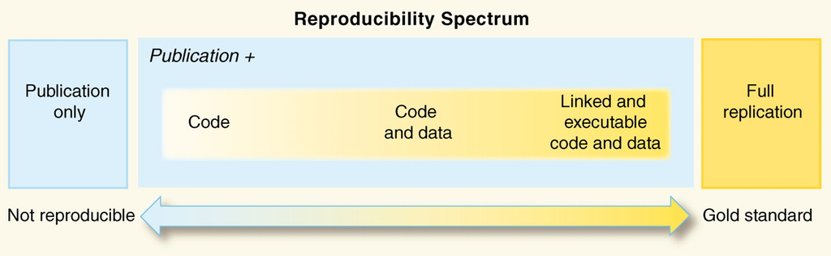

Source : Peng, R. D. 2011. “Reproducible research in computational science”, *Science* 334(6060): 1226–27. https://doi.org/10.1126/science.1213847

### Programmation lettrée

> « Au lieu de considérer que notre tâche principale est de dire à un ordinateur ce qu’il doit faire, appliquons-nous plutôt à expliquer à des êtres humains ce que nous voulons que l’ordinateur fasse. »  
> Knuth, D. 1984. “Literate Programming”, *The Computer Journal* 27(2): 97–111. https://doi.org/10.1093/comjnl/27.2.97
- L’idée est donc de **combiner du texte et du code dans un seul fichier**
  - pour qu’il soit compréhensible à la fois par l’être humain et la machine
  - qui explique à la fois la logique et les résultats du code
  - qui va être interprété par des outils pour produire un document adapté à la lecture par des êtres humains

#### Exemple

##### Programmation “classique”

```
# Création d'un vecteur de nombres
x <- c(1, 2, 3, 4, 5)

# Calcul de la moyenne
moyenne <- mean(x)

# Affichage du résultat
print(moyenne)
```

##### Programmation lettrée

```
# Calcul de la moyenne d'un vecteur en R

Dans cet exemple, nous allons créer un vecteur de cinq nombres entiers et calculer sa moyenne à l'aide de la fonction `mean()`.

# Création du vecteur
x <- c(1, 2, 3, 4, 5)

# Calcul de la moyenne
moyenne <- mean(x)

# Affichage du résultat
print(moyenne)

La fonction `mean()` calcule la moyenne arithmétique des valeurs contenues dans le vecteur `x`. Le résultat est ensuite affiché à l'écran.
```

#### **Résumé de la différence**

| Programmation classique | Programmation lettrée |
| --- | --- |
| Fichier .R | Fichier .rmd, .qmd |
| Code prédominant | Texte prédominant |
| Commentaires brefs | Explications détaillées en texte |
| Lecture orientée code | Lecture orientée documentation |

# Introduction à Quarto

## Présentation de [`Quarto`](https://quarto.org/)

- Système open-source de programmation lettrée, basé sur [`Pandoc`](https://pandoc.org/), qui
  - permet de combiner code informatique et texte dans un même fichier
  - supporte plusieurs langages de programmation : [`R`](https://www.r-project.org/), [`Python`](https://www.python.org/), [`Julia`](https://julialang.org/), [`JavaScript`](https://developer.mozilla.org/fr/docs/Web/JavaScript)
  - propose une syntaxe [`Markdown`](https://www.markdownguide.org/) enrichie pour intégrer code, texte, équations, tableaux et graphiques dans un même fichier `.qmd`
  - génère différents formats de rendu (simultanés) : site web, article PDF, document Word, livre électronique, présentation (notamment au format [`reveal.js`](https://revealjs.com/))
  - est compatible avec différents IDE : [`RStudio`](https://posit.co/products/open-source/rstudio/), [`VSCode`](https://code.visualstudio.com/) par exemple
  - contient des fonctionnalités avancées pour la gestion des références, des figures et des tableaux

$\Rightarrow$ Avec [`Quarto`](https://quarto.org/), résultats et document sont toujours en phase !

- C’est une extension de [`R Markdown`](https://rmarkdown.rstudio.com/) qui ajoute de nouvelles possibilités pour une meilleure flexibilité et collaboration

$\Rightarrow$ C’est un outil très pratique pour la science reproductible

[`Quarto`](https://quarto.org/) facilite la reproductibilité en permettant de combiner texte explicatif, code source et résultats dans un même document, assurant ainsi la traçabilité et la reproductibilité des analyses

## Exemple

- **Script R avec du code R**

```r
#   __________________________________________________________________
#   Script: Analyse des données hdv2003
#   Author: Sandrine
#   __________________________________________________________________

# Chargement des packages
library(ggplot2)

# Chargement des données
data(hdv2003)

# Distribution du nombre d'heures passées devant la TV selon le sexe
hdv2003 |>
  ggplot() +
    aes(x = sexe, y = heures.tv) +
  geom_boxplot()

## ==> Pas de différences entre les groupes
```

- **Script Quarto avec du code R**

[figure not shown]

- **Sortie html d’un document Quarto avec du code R**

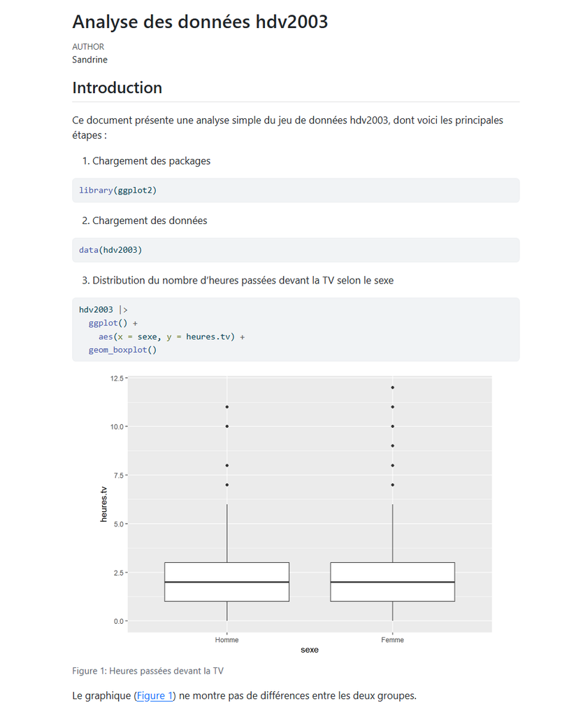

# Premiers pas avec Quarto dans RStudio

## Création d’un premier document Quarto (.qmd)

- Organiser son travail dans un projet RStudio (cf. [Bonnes pratiques à ETTIS](https://statire.github.io/bulledr/01-bonnes_pratiques/#/travailler-en-projets))
- Créer un nouveau document : Menu File > New file > Quarto document
  - dans la fenêtre de dialogue
    - donner un titre
    - indiquer éventuellement l’auteur
    - choisir le format de sortie : HTML, PDF ou Word
    - décocher la case “Use visual markdown editor” : **privilégier le mode “Source”** qui permet de contrôler plus précisément le code

[figure not shown]

  - sauvegarder ce fichier (à la racine du projet ou dans un sous-dossier)
- **Voici à quoi ressemble le fichier *.qmd* créé**

[figure not shown]

## Structure d’un fichier .qmd

### L’en-tête YAML : métadonnées et options du document

- L’en-tête
  - s’écrit avec le langage YAML (initialement *Yet Another Markup Language* puis *YAML Ain’t Markup Language*)
  - est délimitée en haut et en bas, par 3 tirets : “- - -”
  - précise les métadonnées telles que le titre, l’auteur, le titre, la date, etc.
  - permet de définir différentes options sur les formats de sorties et la mise en page
  - permet de paramétrer la langue pour la mise en page, notamment pour la sortie pdf, la génération de la table des matières
- Le YAML est le premier élément évalué lors de la compilation
- La syntaxe est très sensible à l’indentation : **ajouter 2 espaces pour chaque niveau d’indentation**  
  $\Rightarrow$ en cas d’erreur, la compilation s’arrête quasi instantanément !

La gestion de la ponctuation et des guillemets dépend du contenu en markdown ou en texte. Elle n’est pas gérée par une syntaxe spécifique à Quarto.

Pour utiliser les guillemets français dans un document Quarto, il faut taper directement les guillemets français :

**Exemple**  
« On utilise les guillemets français »

#### Version minimale

```yaml
---
title: "Mon premier Quarto"
author: "Sandrine"
format: html
---
```

#### Version plus détaillée

```yaml
---
title: "Mon premier Quarto"
subtitle: "Exemple d'en-tête YAML détaillée"
date: 2025-06-26
author: "Sandrine"
institute: "Inrae ETTIS"
lang: fr
format:
  html:
    toc: true
    number-sections: true
    css: styles.css
editor: source
---
```

**Voir la documentation Quarto pour plus d’informations sur les nombreuses options disponibles**

- section [Front matter](https://quarto.org/docs/authoring/front-matter.html)
- pour le format [HTML](https://quarto.org/docs/reference/formats/html.html)
- pour le format [PDF](https://quarto.org/docs/reference/formats/pdf.html)
- pour le format [Word](https://quarto.org/docs/reference/formats/docx.html)
- pour le format [Revealjs](https://quarto.org/docs/reference/formats/presentations/revealjs.html)
- pour le format [Powerpoint](https://quarto.org/docs/reference/formats/presentations/pptx.html)

### Le corps du document : texte en [`markdown`](https://www.markdownguide.org/) enrichi

- Le texte est balisé avec le langage [`markdown`](https://www.markdownguide.org/) pour la mise en forme
- **Il n’est pas possible de souligner du texte en `markdown`** : le soulignement est réservé aux liens hypertextes
- On peut ajouter du texte, des listes, des tableaux, des liens vers des pages web, des images, etc.  
  [Bases en markdown](https://quarto.org/docs/authoring/markdown-basics.html)
- Cette syntaxe permet de gérer les [citations](https://quarto.org/docs/authoring/citations.html) et les [références croisées](https://quarto.org/docs/authoring/cross-references.html)

#### Syntaxe [`markdown`](https://www.markdownguide.org/) pour la mise en forme du texte

Caractéristique

Syntaxe markdown

Résultat

italic

`texte en *italique*`

texte en *italique*

bold

`texte en **gras**`

texte en **gras**

superscript

`superficie de 200 m^2^`

superficie de 200 m<sup>2</sup>

subscript

`Les individus notés n~i~`

Les individus notés n<sub>i</sub>

strikethrough

`texte ~~barré~~`

texte barré

headings

`# Titre 1`

# Titre 1

`## Titre 2`

## Titre 2

`### Titre 3`

### Titre 3

`#### Titre 4`

#### Titre 4

`##### Titre 5`

##### Titre 5

`###### Titre 6`

###### Titre 6

links

Site `[Quarto](https://quarto.org/)`

Site [Quarto](https://quarto.org/)

visible links

le lien est `<https://quarto.org/>`

le lien est https://quarto.org

quote

`> ceci est important à retenir`

> ceci est important à retenir

#### Syntaxe pour écrire du texte sur plusieurs colonnes

Pour écrire du texte sur plusieurs colonnes, on utilise la balise `:::: {.columns}` puis les sous-blocs `::: {.column}` pour chaque colonne, pour laquelle on peut ajuster la largeur avec le paramètre `width="100%"`

**Syntaxe markdown**

```
 :::: {.columns}

 ::: {.column width="60%"}
 Contenu de la colonne de gauche.
 Texte long possible.
 :::

 ::: {.column width="40%"}
 Contenu de la colonne de droite.
 :::

 ::::
```

**Résultat**

Contenu de la colonne de gauche.  
Texte long possible.

Contenu de la colonne de droite.

**Note**

On ajoute autant de colonnes que nécessaire avec le bloc

```
::: {.column}
Le texte d'une colonne
:::
```

#### Syntaxe pour les listes

##### non ordonnées

**Syntaxe markdown**

```
 * item 1
    + sous-item 1
    + sous-item 2
        - sous-sous item 1
        - sous-sous item 2
 * item 2
```

**Résultat**

- item 1
  - sous-item 1
  - sous-item 2
    - sous-sous item 1
    - sous-sous item 2
- item 2

##### ordonnées

**Syntaxe markdown**

```
 1. item 1
    a) sous-item 1
    b) sous-item 2
        i. sous-sous item 1
        ii. sous-sous item 2
 2. item 2
```

Indentation de 4 espaces

**Résultat**

1. item 1
   1. sous-item 1
   2. sous-item 2
      1. sous-sous item 1
      2. sous-sous item 2
2. item 2

#### Syntaxe pour l’ajout de tableaux

##### Tableaux “manuels”

**Syntaxe markdown**

```
| Colonne 1   | Colonne 2   | Colonne 3   | Colonne 4   |
|:------------|:-----------:|------------:| ----------- |
| Alignement  | Alignement  | Alignement  | Alignement  |
| à gauche    | centré      | à droite    | par défaut  |
: Titre du tableau.
```

**Résultat**

Titre du tableau.

| Colonne 1 | Colonne 2 | Colonne 3 | Colonne 4 |
| --- | --- | --- | --- |
| Alignement | Alignement | Alignement | Alignement |
| à gauche | centré | à droite | par défaut |

L’alignement dans les cellules est contrôlé avec les `:`  
Voir la [page d’aide Quarto dédiée](https://quarto.org/docs/authoring/tables.html) pour les options disponibles  
[Un outil en ligne](https://www.tablesgenerator.com/markdown_tables) pour générer des tableaux `markdown`

##### Tableaux de résultats R

- Affichage par défaut des tableaux

```r
hdv2003 |>
  select(id:qualif) |>
  slice(1:2)
```

```
  id age  sexe                                              nivetud    poids
1  1  28 Femme Enseignement superieur y compris technique superieur 2634.398
2  2  23 Femme                                                 <NA> 9738.396
                  occup  qualif
1 Exerce une profession Employe
2       Etudiant, eleve    <NA>
```

- Affichage avec la fonction `kable()` du package [`{knitr}`](https://yihui.org/knitr/)

```r
hdv2003 |>
  select(id:qualif) |>
  slice(1:2) |>
  knitr::kable()
```

| id | age | sexe | nivetud | poids | occup | qualif |
| --- | --- | --- | --- | --- | --- | --- |
| 1 | 28 | Femme | Enseignement superieur y compris technique superieur | 2634.398 | Exerce une profession | Employe |
| 2 | 23 | Femme | NA | 9738.396 | Etudiant, eleve | NA |

#### Syntaxe pour l’ajout d’images

- L’ajout d’images se fait avec la syntaxe générique suivante

  `![Légende](chemin/image.extension)`

**Syntaxe markdown**  
`![Logo Quarto](img/quarto.png)`

**Résultat**

Logo Quarto

- Bonne pratique = ajouter une description alternative pour améliorer l’accessibilité pour les malvoyants  
  `![Logo Quarto](img/quarto.png){fig-alt="Logo de Quarto"}`
- Des paramétrages possibles pour
  - la taille de l’image
  - l’alignement horizontal
  - une disposition en lignes ou en colonnes dans le cas de plusieurs images

  Voir la [page d’aide Quarto dédiée](https://quarto.org/docs/authoring/figures.html) pour les options disponibles

##### Exemple

**Syntaxe markdown**

```
::: {#fig-logos layout-ncol=2}
![logo1](img/logo_quarto.png){#fig-logo1 width="40%" fig-align="left" fig-alt="Logo de Quarto hexagonal"}

![logo2](img/quarto.png){#fig-logo2 fig-align="right" fig-alt="Logo de Quarto horizontal"}

Deux versions du logo quarto
:::
```

**Résultat**

[figure not shown]

(a) logo1

(b) logo2

Figure 1: Deux versions du logo quarto

#### Syntaxe pour l’ajout d’équations

L’écriture d’équations mathématiques est possible avec la syntaxe LaTeX, en ligne ou en “bloc”

##### Équation au sein d’un texte

**Syntaxe**

```
La célèbre équation d'Einstein est $E = mc^2$.
```

**Résultat**  
La célèbre équation d’Einstein est $E = mc^2$.

##### Équation en bloc centré

**Syntaxe**

```
La célèbre équation d'Einstein est

$$
E = mc^2
$$
```

**Résultat**
La célèbre équation d’Einstein est
$$E = mc^2$$

#### Syntaxe pour l’ajout de blocs spéciaux (*callout blocks*)

- Ces blocs spéciaux sont utiles pour mettre en valeur une information importante (texte, conseil, avertissement, etc.)
- Il existe 5 types prédéfinis de *callout blocks* (note, tip, warning, caution et important) qui se différencient par leurs couleurs et icônes, et qui ont 3 formats de sortie possibles (default, simple ou minimal)

**Structure**

`:::{.callout-type}` *pour spécifier le type de bloc, avec éventuellement l’ajout d’un titre avec `title="Titre de mon bloc"` dans les accolades*  
du texte  
`:::` *pour fermer le bloc*

Voir la [page d’aide Quarto dédiée](https://quarto.org/docs/authoring/markdown-basics.html#callout-blocks) pour les options disponibles

**Exemples**

**callout-note**

Syntaxe d’un bloc de code ‘note’ avec titre et apparence par défaut

```
:::{.callout-note title="*callout-note*" appearance="default"}
Apparence par défaut d'un bloc de code 'note' avec titre
:::
```

Apparence simple d’un bloc de code ‘tip’ sans titre

```
:::{.callout-tip appearance="simple"}
Apparence simple d'un bloc de code 'tip' sans titre
:::
```

Apparence minimale d’un bloc de code ‘warning’ sans titre

```
:::{.callout-warning appearance="minimal"}
Apparence minimale d'un bloc de code 'warning' sans titre
:::
```

**callout-caution**

Apparence simple d’un bloc de code ‘caution’ avec titre

```
:::{.callout-caution title="*callout-caution*" appearance="simple"}
Apparence simple d'un bloc de code 'caution' avec titre
:::
```

Apparence minimale d’un bloc de code ‘important’ avec titre

[output not shown]

### Les blocs de code : import, manipulation, visualisation des données et résultats

- Possibilité d’écrire du code (R, Python, HTML, SQL, Stata, etc.) directement dans le document, dans ce que l’on appelle des **blocs de code** (aussi appelés *chunks*)
- Ce code est exécuté directement dans le document
- Les résultats produits sont insérés automatiquement dans le rendu final
- De nombreuses options permettent de personnaliser l’exécution du code et l’affichage des résultats dans le document final

#### Pourquoi c’est utile ?

Les blocs permettent de  
- générer des rapports “dynamiques”, où code et résultats sont intégrés directement dans le texte  
- garder une trace exacte du code utilisé, ce qui favorise la reproductibilité

$\Rightarrow$ **Très utiles pour intégrer, exécuter et présenter du code et ses résultats dans un seul et même document**

#### Comment écrire un bloc de code ?

- Un bloc de code s’ouvre avec 3 *backticks* `` ``` ``
- On spécifie le langage utilisé entre accolades `{}` sur la première ligne, à la suite des `` ``` ``
- On paramètre les options dans les lignes qui suivent
  - qui commencent par le *hashpipe* `#|`
  - et s’écrivent avec la syntaxe suivante : `option: value`
- On écrit le code dans le langage spécifié
- On ferme le bloc avec 3 *backticks* `` ``` ``

**Il est également possible d’intégrer directement du code dans une phrase (*inline code*), pour mettre en évidence une commande ou afficher le résultat d’un calcul, sans interrompre le texte**

Dans ce cas, on utilise un seul *backtick* ` pour encadrer le code

**Syntaxe**  
L’âge moyen des 2000 observations de hdv2003 est égal à 48.157

**Résultat**  
L’âge moyen des 2000 observations de hdv2003 est égal à 48.157

#### Exemple de bloc de code

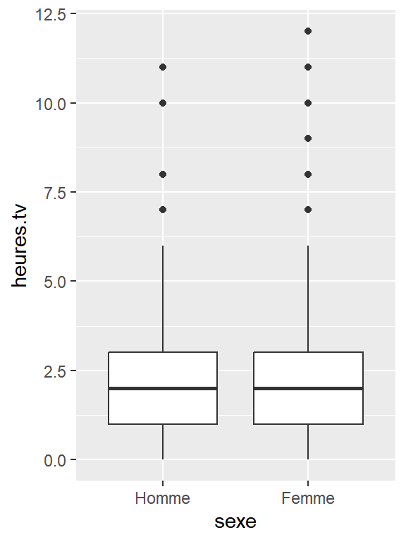

Figure 2: Distribution des heures passées devant la télé selon le sexe

````markdown
```{r}
#| label: fig-exemple
#| eval: true
#| warning: true
#| message: false
#| output: true
#| fig-cap: Distribution des heures passées devant la télé selon le sexe
#| fig-width: 3
#| fig-height: 4
#| fig-align: center

hdv2003 |>
  ggplot() +
  aes(x = sexe, y = heures.tv) +
  geom_boxplot()
```
````

#### Gestion de l’exécution du code de de l’affichage de son résultat

Principales options des blocs de code

| Option | Description |
| --- | --- |
| `eval: true/false` | Exécuter le code du bloc |
| `echo: true/false` | Afficher le code dans le document final |
| `include: true/false` | Contrôler l’inclusion du code et/ou des résultats dans le document final (`false` : supprime tout) |
| `output: true/false/asis` | Afficher les résultats du code (`asis` pour du markdown brut) |
| `warning: true/false` | Inclure les avertissements générés dans le document final |
| `message: true/false` | Afficher dans le document final, les messages générés par le code |
| `label` | Donner un nom au bloc (utile pour le référencer et y faire appel dans le texte) |
| `fig-cap` | Ajouter une légende à une figure générée par le code |
| `fig-width` / `fig-height` | Définir la largeur/hauteur des figures produites par le code |

##### Les labels des blocs de code

- Quelques règles à respecter
  - les labels doivent être uniques dans le document
  - ils sont composés de chiffres et de lettres, les tirets `-` et les underscores `_` sont autorisés, les espaces et caractères spéciaux sont à éviter
  - placer le label de préférence en haut du bloc, avant les autres options
  - pour y faire référence dans le texte
    - les labels des tableaux, doivent être de la forme `tab-`*nom*
    - les labels des figures (images, graphiques) doivent être de la forme `fig`-*nom*
    - utiliser `@nom-du-label` dans le texte
- Exemple

**Syntaxe**  
`Comme illustré dans la @fig-exemple, il n'y a pas de différences entre les groupes.`

**Résultat**  
Comme illustré dans la Figure 2, il n’y a pas de différences entre les groupes.

### Aperçu des principaux formats de sortie (HTML, PDF, Word)

- Le document source étant rédigé, il faut “l’interpréter” pour voir le rendu final
- Principaux formats de sortie
  - HTML : pour des documents interactifs ; format particulièrement bien adapté à la diffusion
  - PDF : pour des documents statiques, avec mise en page fixe ; format particulièrement bien adapté pour les publications scientifiques
  - docx : pour des documents éditables sous Word ; format particulièrement bien adapté au travail collaboratif
  - *slides* : pour les présentations interactives au format HTML (RevealJS), PDF (Beamer) ou Powerpoint ; format particulièrement bien adapté aux présentations pour des colloques, des cours, etc.

Il est donc possible de couvrir différents formats de sortie, à partir d’un même fichier source, en paramétrant le format et les options de rendu, dans l’en-tête YAML

#### Paramétrage pour un format de sortie particulier

**Exemple pour un document au format html**

```yaml
---
title: "Mon premier Quarto"
author: "Sandrine"
format: html
---
```

Le rendu est celui par défaut, sans paramétrage particulier

#### Paramétrage pour plusieurs formats simultanément

**Exemple pour un document avec 3 formats de sortie (HTML, PDF, Word), avec paramétrage par défaut**

```yaml
---
title: "Mon premier Quarto"
author: "Sandrine"
format:
  html: default
  pdf: default
  docx: default
---
```

#### Personnaliser son document de sortie

```yaml
---
title: "Mon premier Quarto"
author: "Sandrine"
format:
  html:
    output-file: index.html # nom du fichier de sortie
    theme: "cosmo"
---
```

##### Créer une table des matières

```yaml
---
title: "Mon premier Quarto"
author: "Sandrine"
format: html
toc: true
---
```

##### Insérer une bibliographie

```yaml
---
title: "Mon premier Quarto"
author: "Sandrine"
format: html
bibliography: mon_fichier.bib
---
```

##### Personnaliser l’apparence

- Pour un document au format HTML : avec les thèmes prédéfinis ou en créant un fichier css
- Pour un document au format Word : créer un modèle sous Word et y faire référence dans l’en-tête YAML

# Ressources

## Pour aller plus loin

De nombreuses ressources en ligne

Documentation officielle [Quarto](https://quarto.org/)  
Tutoriel [Markdown](https://www.markdowntutorial.com/fr/)  
Tutoriel [Quarto](https://quarto.org/docs/get-started/hello/rstudio.html)  
etc.

## Références

Claerbout, J. 1990. « Active documents and reproducible results ». *Stanford Exploration Project Report* 67: 139‑44. https://sepwww.stanford.edu/data/media/public/docs/sep67/jon2/paper_html/index.html.